# Practical Machine Learning Course Project

DataDeanmon

22 December 2015

## Introduction

Using devices such as Jawbone Up, Nike FuelBand, and Fitbit it is now possible to collect a large amount of data about personal activity relatively inexpensively.

One thing that people regularly do is quantify how much of a particular activity they do, but they rarely quantify how well they do it. In this project, data from accelerometers on the belt, forearm, arm, and dumbell was collected from 6 participants that were asked to perform barbell lifts correctly and incorrectly in 5 different ways.

This report summarises the process taken to develop a predictive model to identify the type of exercise performed by the six subjects, using the data collected from the accelerometers.

More information on the Weight Lifting Exercise Dataset is available from: [http://groupware.les.inf.puc-rio.br/har].

## Data sourcing

This section loads the libraries used in the analysis and reads the training and test datasets.

```r
library(dplyr)
library(caret)
library(randomForest)
```

```r
library(rpart)
library(corrplot)
library(GGally)
url1 <- "https://d396qusza40orc.cloudfront.net/predmachlearn/pml-training.csv"
url2 <- "https://d396qusza40orc.cloudfront.net/predmachlearn/pml-testing.csv"

training <- read.csv(url1)
testing <- read.csv(url2)
```

## Data cleansing

Before proceeding, the training dataset has been partitioned into training and testing/validation sets. Additionally, a number of variables have been removed from the training set. These are:  
- variables with significant amounts of missing values  
- timestamp and num_window varibles which are unlikely to contribute to the predictive model  
- X variable denoting row number

```r
set.seed(1298)

inTrain <- createDataPartition(y = training$classe, p = 0.7, list = FALSE)
trainset <- training[inTrain,]
testset <- training[-inTrain,]

#select numerics only
NewTrain <- trainset[, sapply(X = trainset, is.numeric)]

#remove columns with lots of NAs
NewTrain <- NewTrain[, sapply(X = NewTrain, function(x) !any(is.na(x)))]

#remove Timestamp
NewTrain <- NewTrain[, -grep("^raw_timestamp*", names(NewTrain))]

#remove X column
NewTrain <- NewTrain[, -1]

#remove num_window
NewTrain <- NewTrain[, -1]

#add classe back in
classe <- trainset$classe
NewTrain <- cbind(NewTrain, classe)

#add username back in
user_name <- as.factor(trainset$user_name)
NewTrain <- cbind(user_name, NewTrain)
```

## Training the model

Random forest has been selected as the method, as it generally performs well, is able to identify the variables of most importance and is suited to this classification based problem.

```r
ctrl <- trainControl(method = "cv",
                     repeats = 5)

modelFit <- train(as.factor(classe) ~ .,
                   data = NewTrain,
                   trControl = ctrl,
                   method = "rf",
                   ntree = 100)

modelFit
```

```
## Random Forest
##
## 13737 samples
##    53 predictor
##     5 classes: 'A', 'B', 'C', 'D', 'E'
##
## No pre-processing
## Resampling: Cross-Validated (10 fold)
## Summary of sample sizes: 12363, 12365, 12362, 12363, 12364, 12364, ...
## Resampling results across tuning parameters:
##
##   mtry  Accuracy   Kappa      Accuracy SD  Kappa SD
##    2    0.9909006  0.9884885  0.003276213  0.004144391
##   29    0.9923571  0.9903316  0.003382265  0.004279139
##   57    0.9845673  0.9804750  0.005134887  0.006497512
##
## Accuracy was used to select the optimal model using  the largest value.
## The final value used for the model was mtry = 29.
```

```r
varImp(modelFit)
```

```
## rf variable importance
##
##   only 20 most important variables shown (out of 57)
##
##                      Overall
## roll_belt             100.00
## pitch_forearm          59.51
## yaw_belt               51.30
## roll_forearm           42.32
## magnet_dumbbell_y      41.52
## magnet_dumbbell_z      40.79
## pitch_belt             40.13
## accel_dumbbell_y       23.92
## accel_forearm_x        18.55
## roll_dumbbell          17.07
## magnet_dumbbell_x      16.01
## magnet_belt_z          15.43
## magnet_forearm_z       14.53
## total_accel_dumbbell   13.15
## gyros_belt_z           13.05
## accel_dumbbell_z       12.82
## magnet_belt_y          12.67
## accel_belt_z           12.14
## yaw_arm                11.53
## roll_arm               11.13
```

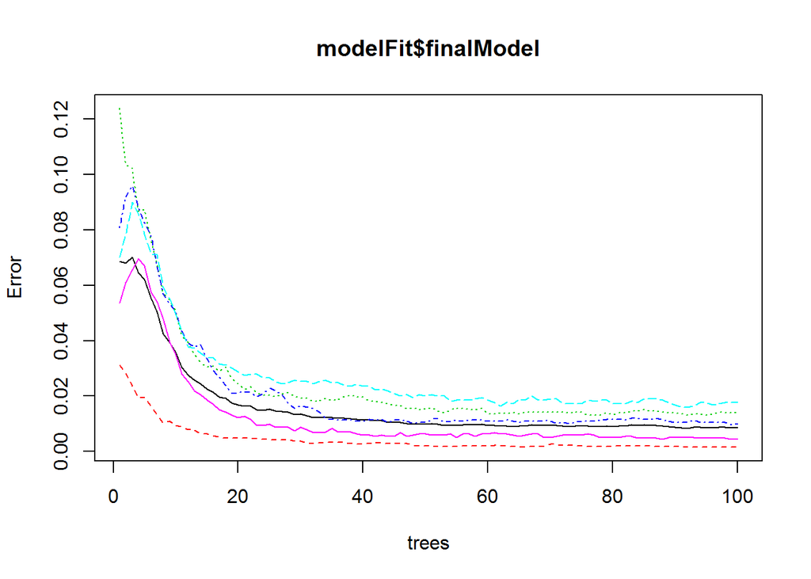

```r
plot(modelFit$finalModel)
```

## Testing the model

This step applies the model obtained through training to the test set that was partitioned for evaluating the model and out of sample error.

```r
predictions <- predict(modelFit, newdata = testset)
confusionMatrix(predictions, testset$classe)
```

```
## Confusion Matrix and Statistics
##
##           Reference
## Prediction    A    B    C    D    E
##          A 1668    6    0    0    0
##          B    6 1130    4    0    1
##          C    0    3 1020    6    1
##          D    0    0    2  957    4
##          E    0    0    0    1 1076
##
## Overall Statistics
##
##                Accuracy : 0.9942
##                  95% CI : (0.9919, 0.996)
##     No Information Rate : 0.2845
##     P-Value [Acc > NIR] : < 2.2e-16
##
##                   Kappa : 0.9927
##  Mcnemar's Test P-Value : NA
##
## Statistics by Class:
##
##                      Class: A Class: B Class: C Class: D Class: E
## Sensitivity            0.9964   0.9921   0.9942   0.9927   0.9945
## Specificity            0.9986   0.9977   0.9979   0.9988   0.9998
## Pos Pred Value         0.9964   0.9904   0.9903   0.9938   0.9991
## Neg Pred Value         0.9986   0.9981   0.9988   0.9986   0.9988
## Prevalence             0.2845   0.1935   0.1743   0.1638   0.1839
## Detection Rate         0.2834   0.1920   0.1733   0.1626   0.1828
## Detection Prevalence   0.2845   0.1939   0.1750   0.1636   0.1830
## Balanced Accuracy      0.9975   0.9949   0.9960   0.9958   0.9971
```

## Predicting the 20 test cases

This final step applies the model to the 20 remaining test cases, which can then be submitted for evaluation.

```r
predictions <- predict(modelFit, newdata = testing)

pml_write_files = function(x){
  n = length(x)
  for(i in 1:n){
    filename = paste0("problem_id_",i,".txt")
    write.table(x[i],file=filename,quote=FALSE,row.names=FALSE,col.names=FALSE)
        }
}

pml_write_files(predictions)
```

## Appendix

These plots illustrate some of the relationships in the dataset that assist interpreting the predictive model.

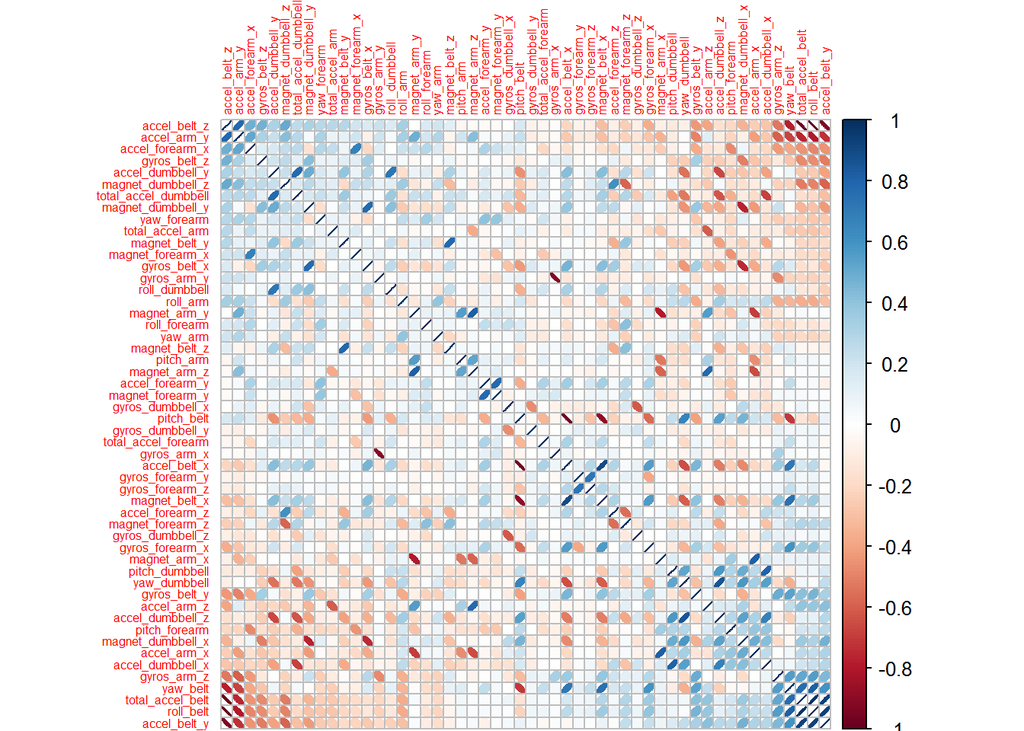

```r
CorrPlot <- NewTrain %>%
        select(-user_name, -classe)
CorrPlot <- cor(CorrPlot)
corrplot(CorrPlot, method = "ellipse", order = "FPC", tl.cex = 0.5)
```